# Chapter 13 End of Chapter Questions

Tyler Richards

## Problem 13.1: TV Brightness

An article in Industrial Quality Control (1956, pp. 5–8) describes an experiment to investigate the effect of glass type and phosphor type on the brightness of a television tube. The response measured is the current necessary (in microamps) to obtain a specified brightness level. The data are shown in Table 13E.1. Analyze the data and draw conclusions.

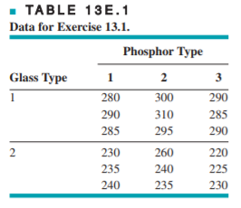

## Problem 13.2: Cutting Tools

A process engineer is trying to improve the life of a cutting tool. He has run a 2^3 experiment using cutting speed (A), metal hardness (B), and cutting angle (C) as the factors. The data from two replicates are shown in Table 13E.2.  
(a) Do any of the three factors affect tool life?  
(b) What combination of factor levels produces the longest tool life?  
(c) Is there a combination of cutting speed and cutting angle that always gives good results regardless of metal hardness?

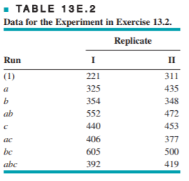

## Problem 13.3: Tool Life Probability Plot

Find the residuals from the tool life experiment in Exercise 13.2. Construct a normal probability plot of the residuals. Plot the residuals versus the predicted values. Comment on the plots.

## Problem 13.4: Soft Drink Experiment

Four factors are thought to possibly influence the taste of a soft-drink beverage: type of sweetener (A), ratio of syrup to water (B), carbonation level (C), and temperature (D). Each factor can be run at two levels, producing a 2^4 design. At each run in the design, samples of the beverage are given to a test panel consisting of 20 people. Each tester assigns a point score from 1 to 10 to the beverage. Total score is the response variable, and the objective is to find a formulation that maximizes total score. Two replicates of this design are run, and the results are shown in Table 13E.3. Analyze the data and draw conclusions.

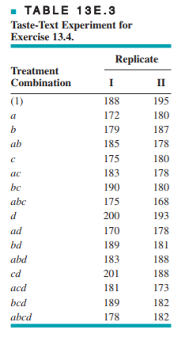

## Problem 13.5: Soft Drink Probability Plots

Consider the experiment in Exercise 13.4. Plot the residuals against the levels of factors A, B, C, and D.  
Also construct a normal probability plot of the residuals. Comment on these plots.